# Tarea 2

Mayela Fosado

16/2/2022

# EJERCICIO 1

Considera las siguientes cantidades discute y justifica qué tipo de distribución de probabilidad pueden tener las siguientes variables:

##### **a. El número (talla) de calzado de adultos varones en México.**

**Distribución unimodal:**

Porque casi todos los adultos varones se distribuyen alrededor del promedio de número de calzado, y son pocos los que tienen un número de calzado fuera del promedio; mayor o menor.

##### **b. La distribución de habitantes en asentamientos humanos de México.**

**Distribución unimodal:**

Porque la mayoría de las personas, viven en asentamientos y son muy pocas las personas que viven aisladas, por lo que se distribuye el promedio, entre ni muchas casas, ni pocas.

##### **c. La velocidad promedio de los automóviles en Bernardo Quintana a las 9 de la mañana en un día laborable.**

**Distribución unimodal:**

Porque al ser una hora transcurrida en Bernardo Quintana, la mayoría de las personas lleva una misma velocidad, para seguir constante y mantener un flujo automovilístico. Así que, todos están alrededor del promedio, el cual puede ser alrededor de 60 km/h (sin tanto tráfico).

##### **d. La velocidad promedio de los automóviles en Bernardo Quintana a las 3 de la mañana.**

**Distribución free-scale:**

Porque al no haber tantos automóviles manejan más rápido que el límite establecido, sobre todo, ya que es una hora en la que muchas personas salen del antro/bar y manejan en condiciones no tan aptas. También puede haber algunos pocos que manejen más lento, para evitar accidentes.

# EJERCICIO 2

Supongamos que tenemos dos nodos (A,B) en una red. El nodo A y B tiene el mismo degree, pero el A tiene un coeficiente de clusterización de 1 y el nodo B un coeficiente bajo. Dibuja está situación y explica cuál sería una mejor diana si quieres eliminarlos y afectar a la red.

[figure not shown]

Red

El mejor para eliminar con el objetivo de afectar la red sería el nodo B, porque si este se elimina se pierde la conectividad con todo el lado de A (nodos rosas). En el otro lado el nodo H también pierde toda su conectividad, y solo quedan conectados entre ellos F y G, debido a que su nivel de clusterización es más bajo, a diferencia de A, si este se elimina, permanece un nodo más conectado que quitando a B.

# EJERCICIO 3

Elabora un programa en R que usando funciones calcule, a partir de una matriz de adyacencia (Sólo utiliza R base para resolver este problema)

```
Crear una matriz:
```

```r
 # Crear una matriz
mat <- matrix(rep(c(0, 1), times = 6), ncol = 3, nrow = 3)
mat
```

```
##      [,1] [,2] [,3]
## [1,]    0    1    0
## [2,]    1    0    1
## [3,]    0    1    0
```

```r
# Agregar nombres para identificar mas facil en el degree
colnames(mat)<- LETTERS [1:3] # Columnas

rownames(mat)<- LETTERS [1:3] # Renglones
mat
```

```
##   A B C
## A 0 1 0
## B 1 0 1
## C 0 1 0
```

**a. Si la red es dirigida o no.**

```r
# Opcion 1, analizando cada elemento - Matriz chiquita

Directed <- function (Directed) {
  if (mat[2,1] == mat [1,2] & mat[3,1] == mat[1,3] & mat[2,3] == mat[3,2]) {  # Verifica si tiene simetria, checando cada elemento en la matriz, a excepcion de 1 y 1 y así sucesivamente, porque ese es 0. (Con una matriz chiquita)
    print ("La matriz es simétrica, por lo tanto No Dirigida")
  } else {
    print ("La matriz no es simétrica, por lo tanto Dirigida")
  }
}
Directed()
```

```
## [1] "La matriz es simétrica, por lo tanto No Dirigida"
```

```r
# Opcion 2, funcion isSymmetric.matrix - Cualquier matriz
 Directed <- function (Directed) {
  if (isSymmetric.matrix (mat) == T) {
  print ("La matriz es simétrica, por lo tanto No Dirigida")
    } else {
  print ("La matriz no es simétrica, por lo tanto Dirigida")
 }
}

Directed()
```

```
## [1] "La matriz es simétrica, por lo tanto No Dirigida"
```

**b. Si la red es pesada o no.**

```r
Pesada <- function (Pesada) {
  if (any(mat > 1) == T) {  # Verifica si existe un valor mayor a 1 en la matriz
    print ("La matriz es pesada")
  } else {
    print ("La matriz no es pesada")
  }
}
Pesada()
```

```
## [1] "La matriz no es pesada"
```

**c. El degree de los nodos.**

```r
Degree <- function (Degree) {

  mat <- ifelse(mat > 1, 1, mat) # en caso de que sea una red pesada, cambia a 1


  deg <- rowSums (mat[1:3,]) # suma los valores en los renglones, para dar el valor del degree de cada uno


  }

Degree()
```

[output not shown]

**d. El histograma del degree.**

[output not shown]

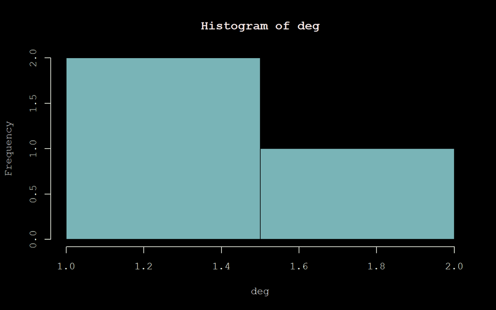